# Test your knowledge of Linear Regression and PCA in R

##### Questions on Linear regression

1. This question involves the use of simple linear regression on the Auto dataset. This dataset was taken from the `StatLib` library which is maintained at Carnegie Mellon University. The dataset has the following fields:
- `mpg`: miles per gallon
- `cylinders`: number of cylinders
- `displacement`: engine displacement (cu. inches)
- `horsepower`: engine horsepower
- `acceleration`: time to accelerate from 0 to 60 mph (sec.)
- `year`: model year (modulo 100)
- `origin`: origin of car (1. American, 2. European, 3. Japanese)
- `name`: vehicle name
  1. Perform a simple linear regression with `mpg` as the response and `horsepower` as the predictor. Comment on why you need to change the `horsepower` variable before performing the regression.  
     *Answer.* Note that the `horsepower` variable is read in as a factor variable due to the presence of “?”. We need to convert this to numeric as shown in the code, to make it a reasonable model.

```r
summary(model1)
```

```
Call:
lm(formula = mpg ~ horsepower, data = auto)

Residuals:
     Min       1Q   Median       3Q      Max
-13.5710  -3.2592  -0.3435   2.7630  16.9240

Coefficients:
             Estimate Std. Error t value Pr(>|t|)
(Intercept) 39.935861   0.717499   55.66   <2e-16 ***
horsepower  -0.157845   0.006446  -24.49   <2e-16 ***
---
Signif. codes:  0 ‘***’ 0.001 ‘**’ 0.01 ‘*’ 0.05 ‘.’ 0.1 ‘ ’ 1

Residual standard error: 4.906 on 390 degrees of freedom
  (5 observations deleted due to missingness)
Multiple R-squared:  0.6059,    Adjusted R-squared:  0.6049
F-statistic: 599.7 on 1 and 390 DF,  p-value: < 2.2e-16
```

2. Comment on the output by answering the following questions: + Is there a strong relationship between the predictor and the response?  
   *Answer.* Yes, there is a strong relationship between the predictor and response. The p-value is almost zero, implying we can reject the null hypothesis that the corresponding $\beta_1= 0$.  
   + Is the relationship between the predictor and the response positive or negative?  
   *Answer.* Since $\hat{\beta}=-0.1578$, there is a negative linear relatioship between mpg and horsepower.
3. What is the predicted mpg associated with a horsepower of 98? What is the associated 99% confidence interval?  
   *Hint*: You can check the `predict.lm` function on how the confidence interval can be computed for predictions with R.  
   *Answer.* The predicted mpg for horsepower of 98 is 24.46708 and the 99% confidence interval is [23.816,25.117].

```r
predict.lm(model1,newdata=data.frame(horsepower=98),interval=c("confidence"),level=.99)
```

```
       fit      lwr      upr
1 24.46708 23.81669 25.11747
```

4. Compute the correlation between the response and the predictor variable. How does this compare with the $R^2$ value?  
   *Answer.* We use `cor(auto$mpg,auto$horsepower, use = "pairwise.complete.obs")` which excludes entries whenever one of the entries is `NA`. Here $R^2=0.6059$.

```r
cor(auto$mpg,auto$horsepower, use = "pairwise.complete.obs")
```

```
[1] -0.7784268
```

5. Plot the response and the predictor. Also plot the least squares regression line.

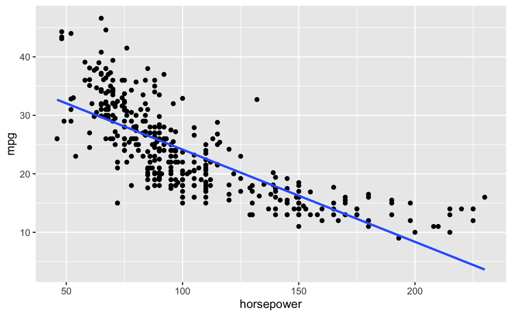

```r
library(ggplot2)
library(ggplot2)
ggplot(auto,aes(horsepower,mpg))+geom_point(na.rm=T)+geom_smooth(method="lm",na.rm=T,se=F)
```

6. First install the package `ggfortify` which aids plotting linear models with `ggplot2`. Use the following two commands in R to produce diagnostic plots of the linear regression fit:  
   `> library(ggfortify)`  
   `> autoplot(your_model_name)`  
   Comment on the Residuals versus Fitted plot and the Normal Q-Q plot and on any problems you might see with the fit.  
   *Answer*. A good linear fit should have the residuals randomly scattered. In this model we see that the residuals decrease, and then increase as the number of fitted residuals increase. The normal QQ plot also shows that the distribution of the residuals is not normal at the extreme tails. This indicates that the data might have evidence of some nonlinearities and outliers.

[output not shown]

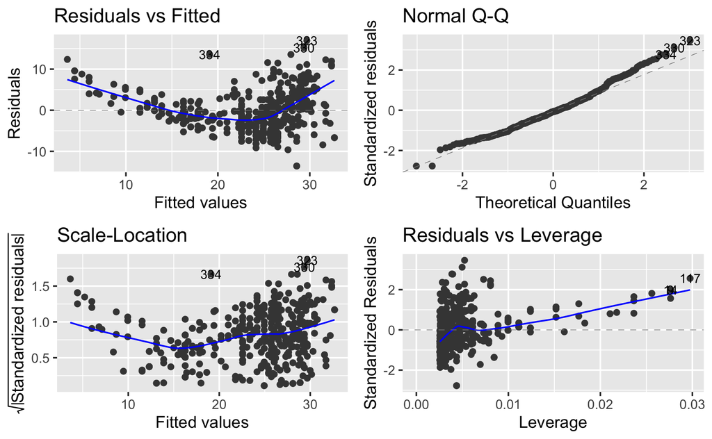

```r
autoplot(model1,label.size = 3)
```

2. This question involves the use of multiple linear regression on the `Auto` dataset building on Question 1.
1. Produce a scatterplot matrix which includes all the variables in the dataset.  
   *Answer.* An easy way to do this is using `pairs(your_data_name)`. Instead we use the package `psych` and `pairs.panel`.

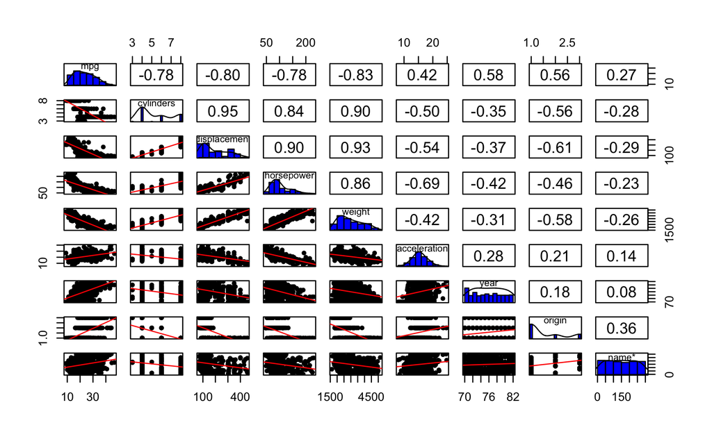

2. Compute a matrix of correlations between the variables using the function `cor()`. You need to exclude the `name` variable which is qualitative.

*Answer.* We use `subset(auto,select=-c(name))` to remove `name` from the set. The presence of `NA` in the variable `horsepower` makes all the correlations with horsepower `NA`.

```r
cor(auto1, use = "pairwise.complete.obs")
```

```
                    mpg  cylinders displacement horsepower     weight acceleration       year
mpg           1.0000000 -0.7762599   -0.8044430 -0.7784268 -0.8317389    0.4222974  0.5814695
cylinders    -0.7762599  1.0000000    0.9509199  0.8429834  0.8970169   -0.5040606 -0.3467172
displacement -0.8044430  0.9509199    1.0000000  0.8972570  0.9331044   -0.5441618 -0.3698041
horsepower   -0.7784268  0.8429834    0.8972570  1.0000000  0.8645377   -0.6891955 -0.4163615
weight       -0.8317389  0.8970169    0.9331044  0.8645377  1.0000000   -0.4195023 -0.3079004
acceleration  0.4222974 -0.5040606   -0.5441618 -0.6891955 -0.4195023    1.0000000  0.2829009
year          0.5814695 -0.3467172   -0.3698041 -0.4163615 -0.3079004    0.2829009  1.0000000
origin        0.5636979 -0.5649716   -0.6106643 -0.4551715 -0.5812652    0.2100836  0.1843141
                 origin
mpg           0.5636979
cylinders    -0.5649716
displacement -0.6106643
horsepower   -0.4551715
weight       -0.5812652
acceleration  0.2100836
year          0.1843141
origin        1.0000000
```

```r
summary(model2)
```

```
Call:
lm(formula = mpg ~ ., data = auto1)

Residuals:
    Min      1Q  Median      3Q     Max
-9.5903 -2.1565 -0.1169  1.8690 13.0604

Coefficients:
               Estimate Std. Error t value Pr(>|t|)
(Intercept)  -17.218435   4.644294  -3.707  0.00024 ***
cylinders     -0.493376   0.323282  -1.526  0.12780
displacement   0.019896   0.007515   2.647  0.00844 **
horsepower    -0.016951   0.013787  -1.230  0.21963
weight        -0.006474   0.000652  -9.929  < 2e-16 ***
acceleration   0.080576   0.098845   0.815  0.41548
year           0.750773   0.050973  14.729  < 2e-16 ***
origin         1.426141   0.278136   5.127 4.67e-07 ***
---
Signif. codes:  0 ‘***’ 0.001 ‘**’ 0.01 ‘*’ 0.05 ‘.’ 0.1 ‘ ’ 1

Residual standard error: 3.328 on 384 degrees of freedom
  (5 observations deleted due to missingness)
Multiple R-squared:  0.8215,    Adjusted R-squared:  0.8182
F-statistic: 252.4 on 7 and 384 DF,  p-value: < 2.2e-16
```

3. This problem focusses on the multicollinearity problem with simulated data.
1. Perform the following commands in R:

```r
y
```

```
  [1] 2.6827672 2.5074326 3.0555319 1.4821751 1.8251307 0.2375940 1.5327832 2.3834094 2.7759413
 [10] 4.8841537 3.2870655 2.9300080 4.5089364 2.8100777 2.0127238 2.3723475 4.3053669 3.2451112
 [19] 2.9970034 3.6281091 3.8198221 2.8916558 2.9033861 3.9769118 3.0330744 4.2496316 2.0703020
 [28] 2.6340310 2.0266098 2.6245772 3.1167674 3.1982041 3.1507935 2.3866268 5.8564449 2.2221731
 [37] 0.8774040 4.3684884 4.7177005 4.2847416 2.8253034 1.5936510 3.9093327 2.0319579 2.2182184
 [46] 4.4816590 2.6748979 4.1548969 1.3502319 2.8866177 2.0305517 1.8625175 5.2816462 2.6397378
 [55] 4.5602006 2.0254032 3.6079664 2.9745802 6.4993732 2.4661052 3.1275804 2.3307390 5.0549749
 [64] 2.4694777 1.5158179 1.5407477 2.9667276 0.1798324 3.3358794 0.6499061 1.2770963 2.7126568
 [73] 1.4622245 3.6180849 4.5953470 5.2598091 1.7217793 1.3105013 3.7566176 2.7265722 2.3563134
 [82] 3.9391263 2.1454937 2.8218094 2.6198138 0.1479057 4.7446359 2.6764253 2.6843838 3.3870835
 [91] 4.6283768 2.6220834 1.9637148 4.5571101 5.0631283 3.5975234 3.5812595 3.5795032 2.7467768
[100] 4.8004811
```

The last line corresponds to creating a linear model in which y is a function of `x1` and `x2`. Write out the form of the linear model. What are the regression coefficients?
*Answer.* The form of the linear model is:
$$y = \beta_0+ \beta_1 x_1 + \beta_2 x_2 +\epsilon$$
where the coefficients are $\beta_0=2, \beta_1=2, \beta_2=0.3$.

```r
ggplot(cbind(x1,x2,y),aes(x1,x2))+geom_point()
```

[output not shown]

3. Using the data, fit a least square regression to predict `y` using `x1` and `x2`.
   - What are the estimated parameters of $\hat{\beta_0}, \hat{\beta_1}$ and $\hat{\beta_2}$? How do these relate to the true ${\beta_0}, {\beta_1}$ and ${\beta_2}$?  
     *Answer.* From the fit we see that $\hat{\beta}_0=2.1305, \hat{\beta}_1=1.4396, \hat{\beta}_2=1.0097$. Since the true values are$\beta_0=2, \beta_1=2, \beta_2=0.3$, there is a discrepancy in the values of $\beta_1, \hat{\beta_1}$ and $\beta_2, \hat{\beta_2}$ but less in the case of $\beta_0, \hat{\beta_0}$
   - Can you reject the null hypothesis $H_0:\beta_1=0$?
   - How about the null hypothesis $H_0:\beta_2=0$?  
     *Answer.* From our regression model, we reject the null hypothesis that $\beta_1=0$ at the 5% level, but we cannot reject the null hypothesis that $\beta_2=0$ at the 5% level. Note that the answers here may change depending on the data simulated, but most of the time we can reject one but not the other.

```r
summary(model3)
```

```
Call:
lm(formula = y ~ x1 + x2)

Residuals:
    Min      1Q  Median      3Q     Max
-2.8311 -0.7273 -0.0537  0.6338  2.3359

Coefficients:
            Estimate Std. Error t value Pr(>|t|)
(Intercept)   2.1305     0.2319   9.188 7.61e-15 ***
x1            1.4396     0.7212   1.996   0.0487 *
x2            1.0097     1.1337   0.891   0.3754
---
Signif. codes:  0 ‘***’ 0.001 ‘**’ 0.01 ‘*’ 0.05 ‘.’ 0.1 ‘ ’ 1

Residual standard error: 1.056 on 97 degrees of freedom
Multiple R-squared:  0.2088,    Adjusted R-squared:  0.1925
F-statistic:  12.8 on 2 and 97 DF,  p-value: 1.164e-05
```

4. Now fit a least squares regression to predict `y` using only `x1`.
   - How does the estimated ${\hat{\beta_1}}$ relate to the true ${\beta_1}$?
   - Can you reject the null hypothesis $H_0:\beta_1=0$?  
     *Answer.* The estimated $\hat{\beta_1}=1.9759$ which close to $\beta_1=2$, and we can reject the null hypothesis that $H_0:\beta_1=0$ as the p-value is close to zero.

```r
summary(model4)
```

```
Call:
lm(formula = y ~ x1)

Residuals:
     Min       1Q   Median       3Q      Max
-2.89495 -0.66874 -0.07785  0.59221  2.45560

Coefficients:
            Estimate Std. Error t value Pr(>|t|)
(Intercept)   2.1124     0.2307   9.155 8.27e-15 ***
x1            1.9759     0.3963   4.986 2.66e-06 ***
---
Signif. codes:  0 ‘***’ 0.001 ‘**’ 0.01 ‘*’ 0.05 ‘.’ 0.1 ‘ ’ 1

Residual standard error: 1.055 on 98 degrees of freedom
Multiple R-squared:  0.2024,    Adjusted R-squared:  0.1942
F-statistic: 24.86 on 1 and 98 DF,  p-value: 2.661e-06
```

5. Now fit a least squares regression to predict `y` using only `x2`.
   - How does the estimated ${\hat{\beta_2}}$ relate to the true ${\beta_2}$?
   - Can you reject the null hypothesis $H_0:\beta_2=0$?  
     *Answer.* The estimated $\hat{\beta_2}=2.8996$ which is quite far from $\beta_2=0.3$. We reject the null hypothesis that $H_0:\beta_2=0$ here as the p-value is close to zero.

```r
summary(model5)
```

```
Call:
lm(formula = y ~ x2)

Residuals:
     Min       1Q   Median       3Q      Max
-2.62687 -0.75156 -0.03598  0.72383  2.44890

Coefficients:
            Estimate Std. Error t value Pr(>|t|)
(Intercept)   2.3899     0.1949   12.26  < 2e-16 ***
x2            2.8996     0.6330    4.58 1.37e-05 ***
---
Signif. codes:  0 ‘***’ 0.001 ‘**’ 0.01 ‘*’ 0.05 ‘.’ 0.1 ‘ ’ 1

Residual standard error: 1.072 on 98 degrees of freedom
Multiple R-squared:  0.1763,    Adjusted R-squared:  0.1679
F-statistic: 20.98 on 1 and 98 DF,  p-value: 1.366e-05
```

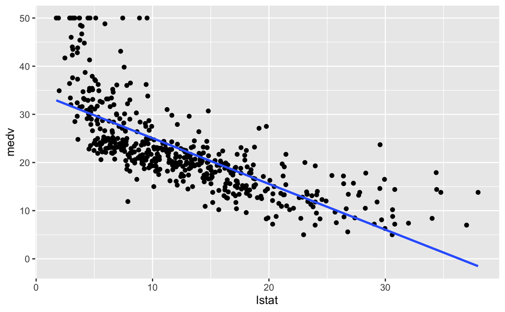

2. Fit a multiple linear regression models to predict your response using all the predictors. Compare the adjusted $R^2$ from this model with the simple regression model. For which predictors, can we reject the null hypothesis $H_0:\beta_j=0$?  
   *Answer.* The adjusted $R^2$ is 0.7338 which is larger than the adjusted $R^2$ from any of the simple regression models. The variables for which we can reject the $H_0: \beta_j=0$ are `crim, zn, chas, nox, rm, dis, rad, tax, ptratio, black, lstat` at the 0.05 significance level.

```r
summary(modelall)
```

```
Call:
lm(formula = medv ~ ., data = boston)

Residuals:
    Min      1Q  Median      3Q     Max
-15.595  -2.730  -0.518   1.777  26.199

Coefficients:
              Estimate Std. Error t value Pr(>|t|)
(Intercept)  3.646e+01  5.103e+00   7.144 3.28e-12 ***
crim        -1.080e-01  3.286e-02  -3.287 0.001087 **
zn           4.642e-02  1.373e-02   3.382 0.000778 ***
indus        2.056e-02  6.150e-02   0.334 0.738288
chas         2.687e+00  8.616e-01   3.118 0.001925 **
nox         -1.777e+01  3.820e+00  -4.651 4.25e-06 ***
rm           3.810e+00  4.179e-01   9.116  < 2e-16 ***
age          6.922e-04  1.321e-02   0.052 0.958229
dis         -1.476e+00  1.995e-01  -7.398 6.01e-13 ***
rad          3.060e-01  6.635e-02   4.613 5.07e-06 ***
tax         -1.233e-02  3.760e-03  -3.280 0.001112 **
ptratio     -9.527e-01  1.308e-01  -7.283 1.31e-12 ***
black        9.312e-03  2.686e-03   3.467 0.000573 ***
lstat       -5.248e-01  5.072e-02 -10.347  < 2e-16 ***
---
Signif. codes:  0 ‘***’ 0.001 ‘**’ 0.01 ‘*’ 0.05 ‘.’ 0.1 ‘ ’ 1

Residual standard error: 4.745 on 492 degrees of freedom
Multiple R-squared:  0.7406,    Adjusted R-squared:  0.7338
F-statistic: 108.1 on 13 and 492 DF,  p-value: < 2.2e-16
```

```r
ggplot(cbind(Ind,All),aes(Ind,All)) + geom_point()+geom_smooth(method="lm",se=F)+ggtitle("Coefficient relationship") + xlab("Simple linear regression") + ylab("Multiple linear regression")
```

[output not shown]

4. In this question, we will check if there is evidence of non-linear association between the `lstat` predictor variable and the response? To answer the question, fit a model of the form  
   `medv` = $\beta_0$+ $\beta_0$`lstat` + $\beta_0$`lstat2` + $\epsilon$.  
   You can make use of the `poly()` function in R. Does this help improve the fit? Add higher degree polynomials to fit the data. What is the degree of the polynomial fit beyond which the terms no longer remain significant?  
   *Answer.* Yes, adding higher-degree terms helps improve the fit. Beyond degree 5, adding additional terms does not seem to improve the model (additional parameters do not remain significant).  
   We plot the data points `(lstat,medv)` along with the linear (blue curve) and polynomial of degree 5 (red curve) fits below.

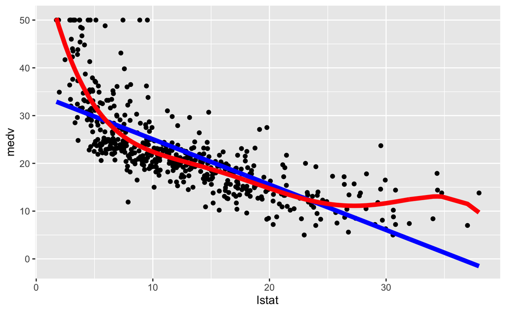

```r
str(wine)
```

```
'data.frame':   25 obs. of  9 variables:
 $ vintage : int  1961 1962 1963 1964 1965 1966 1967 1968 1969 1970 ...
 $ price91 : num  131.5 156 118 92.8 119.6 ...
 $ price92 : num  132 181 180 115 157 ...
 $ temp    : num  18.8 18.8 18 NA 18.6 ...
 $ hrain   : num  20.3 41 42.1 41.1 0.5 ...
 $ wrain   : num  328 411 453 372 374 ...
 $ tempdiff: num  7.36 7.21 6.84 7.76 8.38 7.26 6.88 7.2 6.58 7.47 ...
 $ age91   : num  30 29 28 27 26 25 24 23 22 21 ...
 $ age92   : num  31 30 29 28 27 26 25 24 23 22 ...
```

2. What is the average price of the wines in the 1991 auction that were produced in years when both the harvest rain was below average and the temperature difference was below average?  
   *Answer.* The average price in 1991 when harvest rain and temperature difference were below average is $72.87.

```r
mean(subset(wine$price91,wine$hrain<mean(wine$hrain)&wine$tempdiff<mean(wine$tempdiff)))
```

[output not shown]

3. In this question, you will develop a simple linear regression model to fit the log of the price at which the wine was auctioned in 1991 with the age of the wine. To fit the model, use a training set with data for the wines up to (and including) the year 1981. What is the R-squared for this model?  
   *Answer.* $R^2$ for this model is 0.6675.

```r
summary(model1)
```

```
Call:
lm(formula = log(price91) ~ age91, data = train)

Residuals:
     Min       1Q   Median       3Q      Max
-0.26897 -0.13328  0.01939  0.10452  0.41913

Coefficients:
            Estimate Std. Error t value Pr(>|t|)
(Intercept) 3.571442   0.144163  24.774 6.30e-16 ***
age91       0.042610   0.006899   6.176 6.19e-06 ***
---
Signif. codes:  0 ‘***’ 0.001 ‘**’ 0.01 ‘*’ 0.05 ‘.’ 0.1 ‘ ’ 1

Residual standard error: 0.1914 on 19 degrees of freedom
Multiple R-squared:  0.6675,    Adjusted R-squared:   0.65
F-statistic: 38.15 on 1 and 19 DF,  p-value: 6.188e-06
```

4. Find the 99% confidence interval for the estimated coefficients from the regression.  
   *Answer.*  
   For `intercept` ($\beta_0$): [3:159; 3:98].  
   For `age`($\beta_1$): [0:022; 0:062].

```r
confint(model1, level = 0.99)
```

```
                 0.5 %     99.5 %
(Intercept) 3.15900093 3.98388288
age91       0.02287254 0.06234705
```

5. Use the model to predict the log of prices for wines made from 1982 onwards and auctioned in 1991. What is the test R-squared?  
   *Answer.* Test $R^2=0.9213742.$

```r
testR2
```

```
[1] 0.9213742
```

6. Which among the following options describes best the quality of fit of the model for this dataset in comparison with the Bordeaux wine dataset that was analyzed by Orley Ashenfelter?
   - The result indicates that the variation of the prices of the wines in this dataset is explained much less by the age of the wine in comparison to Bordeaux wines.
   - The result indicates that the variation of the prices of the wines in this dataset is explained much more by the age of the wine in comparison to Bordeaux wines.
   - The age of the wine has no predictive power on the wine prices in both the datasets.  
     *Answer.* In comparison to the results for the Bordeaux wine data, the training (model) $R^2$ and test $R^2$ is higher for this new dataset. This seems to indicate that the variation in the prices of the wine in this dataset is explained much more by the age of the wines in comparison to the Bordeaux dataset.
7. Construct a multiple regression model to fit the log of the price at which the wine was auctioned in 1991 with all the possible predictors (`age91, temp, hrain, wrain, tempdiff`) in the training dataset. To fit your model, use the data for wines made up to (and including) the year 1981. What is the R-squared for the model?  
   *Answer.* For this model $R^2=0.7938.$

```r
summary(model2)
```

```
Call:
lm(formula = log(price91) ~ temp + hrain + wrain + tempdiff +
    age91, data = train)

Residuals:
     Min       1Q   Median       3Q      Max
-0.32298 -0.07019 -0.01634  0.11051  0.24455

Coefficients:
              Estimate Std. Error t value Pr(>|t|)
(Intercept)  2.2626138  1.4914578   1.517   0.1532
temp         0.1135015  0.0734344   1.546   0.1462
hrain       -0.0028825  0.0016205  -1.779   0.0987 .
wrain        0.0002520  0.0003918   0.643   0.5313
tempdiff    -0.1213280  0.1445947  -0.839   0.4166
age91        0.0482331  0.0075346   6.402 2.34e-05 ***
---
Signif. codes:  0 ‘***’ 0.001 ‘**’ 0.01 ‘*’ 0.05 ‘.’ 0.1 ‘ ’ 1

Residual standard error: 0.1803 on 13 degrees of freedom
  (2 observations deleted due to missingness)
Multiple R-squared:  0.7938,    Adjusted R-squared:  0.7145
F-statistic: 10.01 on 5 and 13 DF,  p-value: 0.000421
```

```r
summary(model3)
```

```
Call:
lm(formula = log(price91) ~ age91, data = train)

Residuals:
     Min       1Q   Median       3Q      Max
-0.26897 -0.13328  0.01939  0.10452  0.41913

Coefficients:
            Estimate Std. Error t value Pr(>|t|)
(Intercept) 3.571442   0.144163  24.774 6.30e-16 ***
age91       0.042610   0.006899   6.176 6.19e-06 ***
---
Signif. codes:  0 ‘***’ 0.001 ‘**’ 0.01 ‘*’ 0.05 ‘.’ 0.1 ‘ ’ 1

Residual standard error: 0.1914 on 19 degrees of freedom
Multiple R-squared:  0.6675,    Adjusted R-squared:   0.65
F-statistic: 38.15 on 1 and 19 DF,  p-value: 6.188e-06
```

8. Is this model preferred to the model with only the age variable as a predictor (use the adjusted R-squared for the model to decide on this)?  
   *Answer.* With only the age variable, adjusted $R^2=0.65$. On the other hand, with all the variables, adjusted $R^2=0.7145$. This seems to indicate that the latter model (with more variables included) is preferred.
9. Which among the following best describes the output from the fitted model?
   - The result indicates that less the temperature, the better is the price and quality of the wine
   - The result indicates that greater the temperature difference, the better is the price and quality of wine.
   - The result indicates that lesser the harvest rain, the better is the price and quality of the wine.
   - The result indicates that winter rain is a very important variable in the fit of the data.  
     *Answer.* The result indicates that the lesser the harvest rain, the better the price and the quality of the wine will be. This is because the corresponding $\beta=-0.003$ and is significant at the 10% level. All other statements appear to be false.
10. Of the five variables (`age91, temp, hrain, wrain, tempdiff`), drop the two variables that are the least significant from the results in (g). Rerun the linear regression and write down your fitted model.  
    *Answer.* The least significant variables are `wrain` and `tempdiff` with p-values 0.53 and 0.416 respectively and we create `model3` removing the two.

```r
summary(model3)
```

```
Call:
lm(formula = log(price91) ~ temp + hrain + age91, data = train)

Residuals:
     Min       1Q   Median       3Q      Max
-0.32198 -0.09905  0.00491  0.14536  0.29828

Coefficients:
             Estimate Std. Error t value Pr(>|t|)
(Intercept)  1.801013   1.297697   1.388    0.185
temp         0.097500   0.068750   1.418    0.177
hrain       -0.001983   0.001236  -1.604    0.130
age91        0.045670   0.006702   6.814 5.85e-06 ***
---
Signif. codes:  0 ‘***’ 0.001 ‘**’ 0.01 ‘*’ 0.05 ‘.’ 0.1 ‘ ’ 1

Residual standard error: 0.1752 on 15 degrees of freedom
  (2 observations deleted due to missingness)
Multiple R-squared:  0.7753,    Adjusted R-squared:  0.7304
F-statistic: 17.26 on 3 and 15 DF,  p-value: 3.973e-05
```

11. Is this model preferred to the model with all variables as predictors (use the adjusted R-squared in the training set to decide on this)?  
    *Answer.* In the training set, adjusted $R^2$ for this model is 0.73 while for `model2`, adjsuted $R^2$ is 0.7145. In this case, the new `model3` is preferred to `model2`.
12. Using the variables identified in (j), construct a multiple regression model to fit the log of the price at which the wine was auctioned in 1992 (remember to use `age92` instead of `age91`). To fit your model, use the data for wines made up to (and including) the year 1981. What is the R-squared for the model?  
    *Answer.* $R^2$ for this model is 0.5834.

```r
summary(model4)
```

```
Call:
lm(formula = log(price92) ~ temp + hrain + age92, data = train)

Residuals:
     Min       1Q   Median       3Q      Max
-0.29394 -0.15545  0.03238  0.10221  0.37661

Coefficients:
             Estimate Std. Error t value Pr(>|t|)
(Intercept)  2.723393   1.574961   1.729 0.104296
temp         0.072494   0.083333   0.870 0.398043
hrain       -0.001539   0.001498  -1.027 0.320713
age92        0.035237   0.008124   4.338 0.000586 ***
---
Signif. codes:  0 ‘***’ 0.001 ‘**’ 0.01 ‘*’ 0.05 ‘.’ 0.1 ‘ ’ 1

Residual standard error: 0.2123 on 15 degrees of freedom
  (2 observations deleted due to missingness)
Multiple R-squared:  0.5834,    Adjusted R-squared:  0.5001
F-statistic: 7.002 on 3 and 15 DF,  p-value: 0.003621
```

13. Suppose in this application, we assume that a variable is statistically significant at the 0.2 level. Would you reject the hypothesis that the coefficient for the variable `hrain` is zero?  
    *Answer.* The p-value for hrain is 0.32. Hence we canot reject the null hypothesis that the coefficient for `hrain` is zero.
14. By separately estimating the equations for the wine prices for each auction, we can better establish the credibility of the explanatory variables because:
    - We have more data to fit our models with.
    - The effect of the weather variables and age of the wine (sign of the estimated coeffi- cients) can be checked for consistency across years.
    - 1991 and 1992 are the markets when the Australian wines were traded heavily. Select the best option.  
      *Answer.* The best explanation seems to be that we can check for consistency of the effect of weather variables and age by looking at the sign of the estimated coefficients.
15. The current fit of the linear regression using the weather variables drops all observations where any of the entries are missing. Provide a short explanation on when this might not be a reasonable approach to use.  
    *Answer.* Clearly, dropping missing entries is reliable. However, if there are many missing entries, then this implies we can lose a lot of data.

##### Questions on PCA

6. This question involves the use of principal component analysis on the well-known `iris` dataset. The dataset is available in R.
1. How many observations are there in the dataset? What are the different fields/attributes in the data set?  
   *Answer.* There are 150 observations. There are four different attributes (of type numeric): *Sepal length, Sepal width, Petal length* and *Petal width*. The fifth field gives the *Species* which are of three types: *setosa, versicolor, virginica*.

|  | Sepal.Length | Sepal.Width | Petal.Length | Petal.Width | Species |
| --- | --- | --- | --- | --- | --- |
| 1 | 5.1 | 3.5 | 1.4 | 0.2 | setosa |
| 2 | 4.9 | 3.0 | 1.4 | 0.2 | setosa |
| 3 | 4.7 | 3.2 | 1.3 | 0.2 | setosa |
| 4 | 4.6 | 3.1 | 1.5 | 0.2 | setosa |
| 5 | 5.0 | 3.6 | 1.4 | 0.2 | setosa |
| 6 | 5.4 | 3.9 | 1.7 | 0.4 | setosa |

2. Create a new dataset `iris.data` by removing the `Species` column and store its content as `iris.sp`.

```r
iris.sp
```

```
  [1] setosa     setosa     setosa     setosa     setosa     setosa     setosa     setosa     setosa     setosa     setosa     setosa     setosa
 [14] setosa     setosa     setosa     setosa     setosa     setosa     setosa     setosa     setosa     setosa     setosa     setosa     setosa
 [27] setosa     setosa     setosa     setosa     setosa     setosa     setosa     setosa     setosa     setosa     setosa     setosa     setosa
 [40] setosa     setosa     setosa     setosa     setosa     setosa     setosa     setosa     setosa     setosa     setosa     versicolor versicolor
 [53] versicolor versicolor versicolor versicolor versicolor versicolor versicolor versicolor versicolor versicolor versicolor versicolor versicolor
 [66] versicolor versicolor versicolor versicolor versicolor versicolor versicolor versicolor versicolor versicolor versicolor versicolor versicolor
 [79] versicolor versicolor versicolor versicolor versicolor versicolor versicolor versicolor versicolor versicolor versicolor versicolor versicolor
 [92] versicolor versicolor versicolor versicolor versicolor versicolor versicolor versicolor versicolor virginica  virginica  virginica  virginica
[105] virginica  virginica  virginica  virginica  virginica  virginica  virginica  virginica  virginica  virginica  virginica  virginica  virginica
[118] virginica  virginica  virginica  virginica  virginica  virginica  virginica  virginica  virginica  virginica  virginica  virginica  virginica
[131] virginica  virginica  virginica  virginica  virginica  virginica  virginica  virginica  virginica  virginica  virginica  virginica  virginica
[144] virginica  virginica  virginica  virginica  virginica  virginica  virginica
Levels: setosa versicolor virginica
```

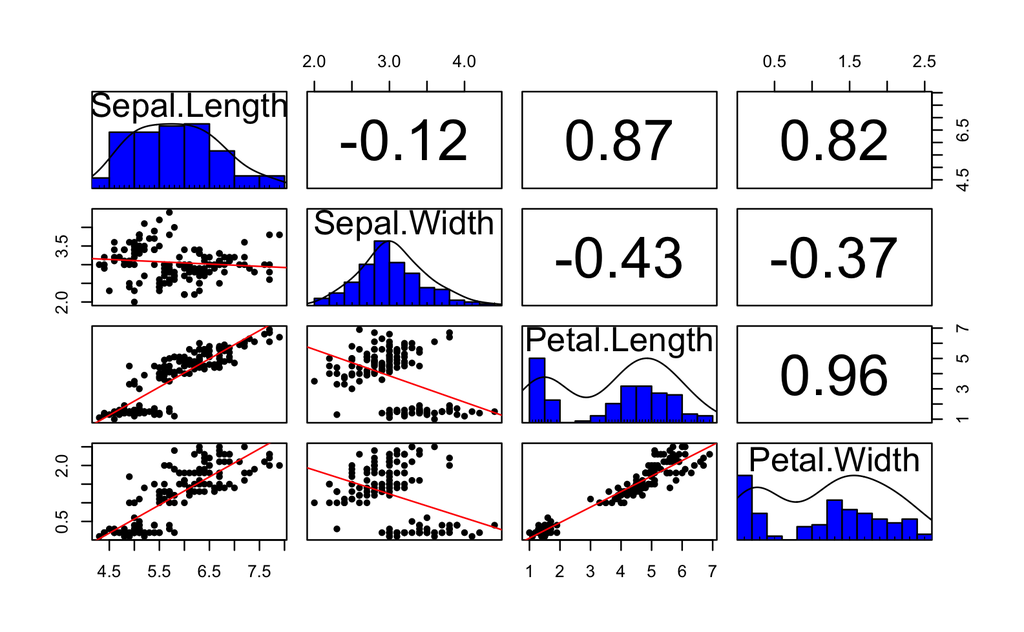

4. Conduct a principal component analysis on `iris.data` without standardizing the data. You may use `prcomp(..., scale=F)`.
   1. How many principal components are required to explain at least 90% of the variability in the data? Plot the cumulative percentage of variance explained by the principal components to answer this question.  
      *Answer.* Clearly in this case, the first principal component already explains more than 90% of the variability in the data set.

```r
pr.out
```

```
Standard deviations (1, .., p=4):
[1] 2.0562689 0.4926162 0.2796596 0.1543862

Rotation (n x k) = (4 x 4):
                     PC1         PC2         PC3        PC4
Sepal.Length  0.36138659 -0.65658877  0.58202985  0.3154872
Sepal.Width  -0.08452251 -0.73016143 -0.59791083 -0.3197231
Petal.Length  0.85667061  0.17337266 -0.07623608 -0.4798390
Petal.Width   0.35828920  0.07548102 -0.54583143  0.7536574
```

In general it is suggested that data be scaled prior to conducting PCA.  
ii) Plot the data along the first two principal components and color the different species separately. Does the first principal component create enough separation among the different species? To plot, you may use the function `fviz_pca_ind` or `fviz_pca_biplot` in `library(factoextra)`. Alternatively, you may use `biplot` or construct a plot using `ggplot2` as well.  
*Answer.* The first principal component already seems to create a separation between setosa and the other two categories, although versicolor seems to be quite close to virginica. Moreover, it appears the same proportions of Petal length and Petal width are used in both PC1 and PC2 (the only difference is the magnitude). We can also create 95% confidence bounds of ellipses around the groups to see how much they are separated.

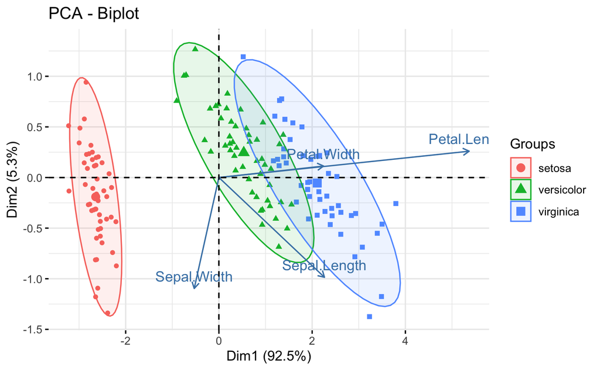

5. Do the same exercise as in (d) above, now after standardizing the dataset. Comment on any differences you observe.  
   *Answer.* From the standardized PCA, we observe that it requires two principal components to explain more than 90% of the variability in the data (actually then we explain 95%).

When data is standardized, one guideline to pick the number of relevant principal components is to pick the ones with eigen-values (the variances of each components) greater than 1 (which means they explain at least one variable). Check that sum of the eigen-values (variances) is the number of variables (which is four here).

```r
pr.out.sc
```

```
Standard deviations (1, .., p=4):
[1] 1.7083611 0.9560494 0.3830886 0.1439265

Rotation (n x k) = (4 x 4):
                    PC1         PC2        PC3        PC4
Sepal.Length  0.5210659 -0.37741762  0.7195664  0.2612863
Sepal.Width  -0.2693474 -0.92329566 -0.2443818 -0.1235096
Petal.Length  0.5804131 -0.02449161 -0.1421264 -0.8014492
Petal.Width   0.5648565 -0.06694199 -0.6342727  0.5235971
```

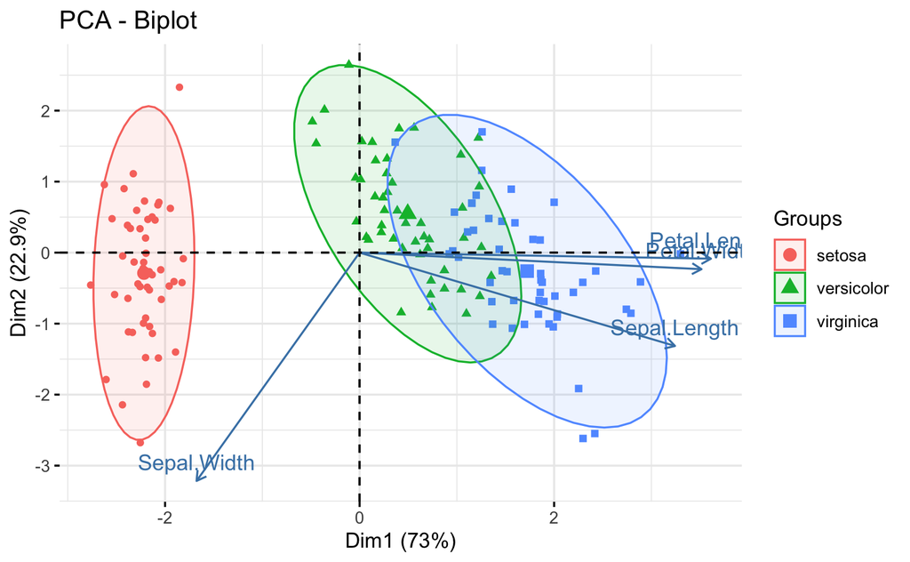

```r
str(wineitaly)
```

```
'data.frame':   178 obs. of  14 variables:
 $ class        : int  1 1 1 1 1 1 1 1 1 1 ...
 $ alcohol      : num  14.2 13.2 13.2 14.4 13.2 ...
 $ malic        : num  1.71 1.78 2.36 1.95 2.59 1.76 1.87 2.15 1.64 1.35 ...
 $ ash          : num  2.43 2.14 2.67 2.5 2.87 2.45 2.45 2.61 2.17 2.27 ...
 $ alkalin      : num  15.6 11.2 18.6 16.8 21 15.2 14.6 17.6 14 16 ...
 $ magnesium    : int  127 100 101 113 118 112 96 121 97 98 ...
 $ phenols      : num  2.8 2.65 2.8 3.85 2.8 3.27 2.5 2.6 2.8 2.98 ...
 $ flavanoids   : num  3.06 2.76 3.24 3.49 2.69 3.39 2.52 2.51 2.98 3.15 ...
 $ nonflavanoids: num  0.28 0.26 0.3 0.24 0.39 0.34 0.3 0.31 0.29 0.22 ...
 $ proanth      : num  2.29 1.28 2.81 2.18 1.82 1.97 1.98 1.25 1.98 1.85 ...
 $ color        : num  5.64 4.38 5.68 7.8 4.32 6.75 5.25 5.05 5.2 7.22 ...
 $ hue          : num  1.04 1.05 1.03 0.86 1.04 1.05 1.02 1.06 1.08 1.01 ...
 $ od280        : num  3.92 3.4 3.17 3.45 2.93 2.85 3.58 3.58 2.85 3.55 ...
 $ proline      : int  1065 1050 1185 1480 735 1450 1290 1295 1045 1045 ...
```

2. Conduct a principal component analysis on the standardized data. What proportion of the total variability in the data is explained by the first two components?

*Answer.* The first two components explain 55% of the total variation.

```r
summary(pr.wine)
```

```
Importance of components:
                         PC1    PC2    PC3     PC4     PC5     PC6     PC7     PC8     PC9   PC10    PC11
Standard deviation     2.169 1.5802 1.2025 0.95863 0.92370 0.80103 0.74231 0.59034 0.53748 0.5009 0.47517
Proportion of Variance 0.362 0.1921 0.1112 0.07069 0.06563 0.04936 0.04239 0.02681 0.02222 0.0193 0.01737
Cumulative Proportion  0.362 0.5541 0.6653 0.73599 0.80162 0.85098 0.89337 0.92018 0.94240 0.9617 0.97907
                          PC12    PC13
Standard deviation     0.41082 0.32152
Proportion of Variance 0.01298 0.00795
Cumulative Proportion  0.99205 1.00000
```

3. Plot the data along the first two principal components and color the different cultivars separately. Also plot the loadings of the different components to show the importance of the different attributes on the first two principal components?  
   *Answer.*

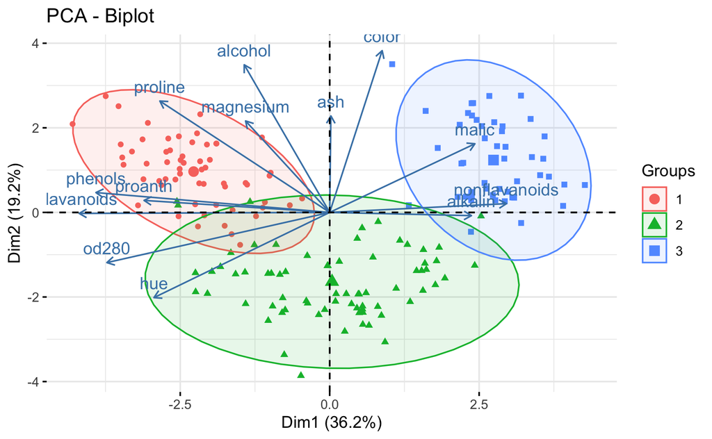

```
i) Which two key attributes differentiate Cultivar 2 from the other two cultivars?
```

*Answer.* From the principal component loadings for each attribute, we can see that *Cultivar 2* (green triangles) has lighter color intensity and lower alcohol content (plotted opposite to the directions of these attributes in the PC1-PC2 axes). They also have a higher OD280/OD315 ratio and stronger hue than the other cultivars (but these weights are a little less that the first two).

```r
pr.wine$rotation[order(pr.wine$rotation[,2],decreasing=T),1:2] ## order according to PC2
```

```
                       PC1          PC2
color          0.088616705  0.529995672
alcohol       -0.144329395  0.483651548
proline       -0.286752227  0.364902832
ash            0.002051061  0.316068814
magnesium     -0.141992042  0.299634003
malic          0.245187580  0.224930935
phenols       -0.394660845  0.065039512
proanth       -0.313429488  0.039301722
nonflavanoids  0.298533103  0.028779488
flavanoids    -0.422934297 -0.003359812
alkalin        0.239320405 -0.010590502
od280         -0.376167411 -0.164496193
hue           -0.296714564 -0.279235148
```

```
ii) Which two key attributes differentiate Cultivar 3 from the other two cultivars?
```

*Answer.* Similarly we can see that *Cultivar 3* (blue squares) has higher content of malic acid and non-flavanoids, as well as higher alkalinity especially with respect to cultivar 1.

```
integer(0)
```

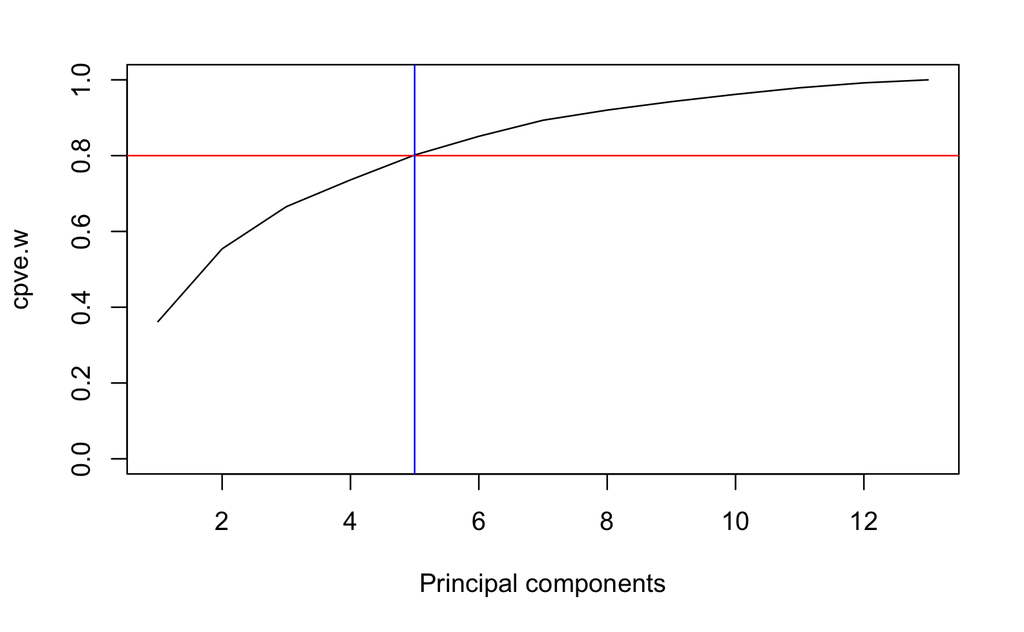

```r
plot(cpve.w,xlab="Principal components",type="l",ylim=c(0,1))+abline(h=0.8,col="red")+abline(v=5,col="blue")
```